# Reporte de proyecto

Daniela Goretti Castillo León

7/2/2022

## ANÁLISIS DE EXPRESIÓN DIFERENCIAL DEL PROYECTO SRP131764

# Resumen

# Introducción

El trastorno del espectro autista es una condición que se caracteriza por diferencias en el comportamiento y la comunicación de quienes la padecen. Se presenta en seres humanos sin importar raza, género o condición socioeconómica.

En el proyecto SRP131764, o mejor dicho “Gut Microbiota from Human Autism Spectrum Disorder Induces Behavioral Deficits in Mice”, se transfirió microbiota vía fecal a ratones silvestres sanos. Los animales con el microbioma alterado presentaron cambios a nivel social, vocal y estereotípico, conductas asociadas con el espectro autista. Asimismo, en los ratones se halló la expresión de ciertos genes relacionados con la actividad cerebral de personas con esta condición.

En este reporte se hará un análisis de este proyecto a través de recount3.

# Método

1. Se cargan las librerías recount3, edgeR, ggplot2, limma y pheatmap al inicio del programa 01-analisis.R.

```r
library(recount3)
library(edgeR)
```

```r
library(ggplot2)
library(limma)
library(pheatmap)
```

2. Escribimos los comandos para la obtención de los siguientes pasos para analizar la expresión diferencial:
- Descargar el estudio deseado de la página de recount3.

```r
rse_SRP131764 <- recount3::create_rse_manual(
    project = "SRP131764",
    project_home = "data_sources/sra",
    organism = "mouse",
    annotation = "gencode_v23",
    type = "gene"
)
```

```
## 2022-02-14 01:34:29 downloading and reading the metadata.
```

```
## 2022-02-14 01:34:31 caching file sra.sra.SRP131764.MD.gz.
```

```
## 2022-02-14 01:34:43 caching file sra.recount_project.SRP131764.MD.gz.
```

```
## 2022-02-14 01:34:47 caching file sra.recount_qc.SRP131764.MD.gz.
```

```
## 2022-02-14 01:34:49 caching file sra.recount_seq_qc.SRP131764.MD.gz.
```

```
## 2022-02-14 01:34:50 caching file sra.recount_pred.SRP131764.MD.gz.
```

```
## 2022-02-14 01:34:52 downloading and reading the feature information.
```

```
## 2022-02-14 01:34:53 caching file mouse.gene_sums.M023.gtf.gz.
```

```
## 2022-02-14 01:34:55 downloading and reading the counts: 138 samples across 55421 features.
```

```
## 2022-02-14 01:34:56 caching file sra.gene_sums.SRP131764.M023.gz.
```

```
## 2022-02-14 01:35:10 construcing the RangedSummarizedExperiment (rse) object.
```

- Guardar cuentas de genes presentes en muestras.

```r
assay(rse_SRP131764, "counts") <- compute_read_counts(rse_SRP131764)
```

- Ver los atributos de las muestras.

```r
attributes <- expand_sra_attributes(rse_SRP131764)
colData(attributes)[, grepl("^sra_attribute", colnames(colData(attributes)))]
```

```
## DataFrame with 138 rows and 6 columns
##            sra_attribute.age sra_attribute.mouse_status sra_attribute.Sex
##                  <character>                <character>       <character>
## SRR6652436               P45     colonized with Human..              male
## SRR6652443               P45     colonized with Human..              male
## SRR6652469               P45     colonized with Human..              male
## SRR6652471               P45     colonized with Human..              male
## SRR6652505               P45     colonized with Human..              male
## ...                      ...                        ...               ...
## SRR6652520               P45     colonized with Human..              male
## SRR6652523               P45     colonized with Human..              male
## SRR6652524               P45     colonized with Human..              male
## SRR6652525               P45     colonized with Human..              male
## SRR6652526               P45     colonized with Human..              male
##            sra_attribute.source_name sra_attribute.strain_background
##                          <character>                     <character>
## SRR6652436            Striatum_ASD 3                        C57BL/6J
## SRR6652443        Striatum_control 4                        C57BL/6J
## SRR6652469    PrefrontalCortex_ASD 3                        C57BL/6J
## SRR6652471    PrefrontalCortex_con..                        C57BL/6J
## SRR6652505    PrefrontalCortex_ASD 3                        C57BL/6J
## ...                              ...                             ...
## SRR6652520    PrefrontalCortex_con..                        C57BL/6J
## SRR6652523    PrefrontalCortex_ASD 3                        C57BL/6J
## SRR6652524    PrefrontalCortex_ASD 3                        C57BL/6J
## SRR6652525    PrefrontalCortex_ASD..                        C57BL/6J
## SRR6652526    PrefrontalCortex_ASD..                        C57BL/6J
##              sra_attribute.tissue
##                       <character>
## SRR6652436 macro-dissected Stri..
## SRR6652443 macro-dissected Stri..
## SRR6652469 macro-dissected pref..
## SRR6652471 macro-dissected pref..
## SRR6652505 macro-dissected pref..
## ...                           ...
## SRR6652520 macro-dissected pref..
## SRR6652523 macro-dissected pref..
## SRR6652524 macro-dissected pref..
## SRR6652525 macro-dissected pref..
## SRR6652526 macro-dissected pref..
```

- Guardar las variables de interés (origen fecal, relación del gen con la muestra y y tejido).

```r
attributes$sra_attribute.mouse_status <- as.factor(attributes$sra_attribute.mouse_status)

attributes$sra_attribute.source_name <- as.factor(attributes$sra_attribute.source_name)

attributes$sra_attribute.tissue <- as.factor(attributes$sra_attribute.tissue)
```

- Cambiar nombre de tipo de origen de microbioma.

```r
attributes$sra_attribute.mouse_status <- factor(ifelse(attributes$sra_attribute.mouse_status == "colonized with Human feces (ASD)", "ASD-feces", "control-feces"))
```

- Comparar cuentas de atributos.

```r
attributes$assigned_gene_prop <- attributes$recount_qc.gene_fc_count_all.assigned / attributes$recount_qc.gene_fc_count_all.total
summary(attributes$assigned_gene_prop)
```

```
##    Min. 1st Qu.  Median    Mean 3rd Qu.    Max.
##  0.7265  0.7692  0.7761  0.7759  0.7831  0.7988
```

- Plotear atributos.

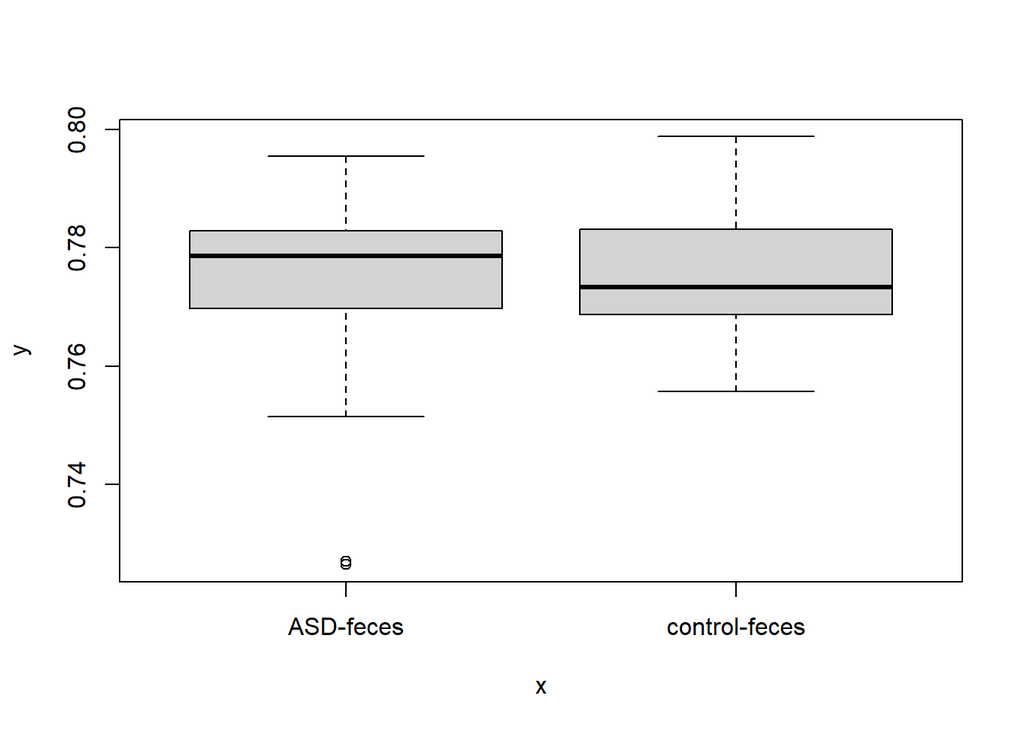

```r
with(colData(attributes), plot(sra_attribute.mouse_status, assigned_gene_prop))
```

- Realizar un filtrado de los datos.

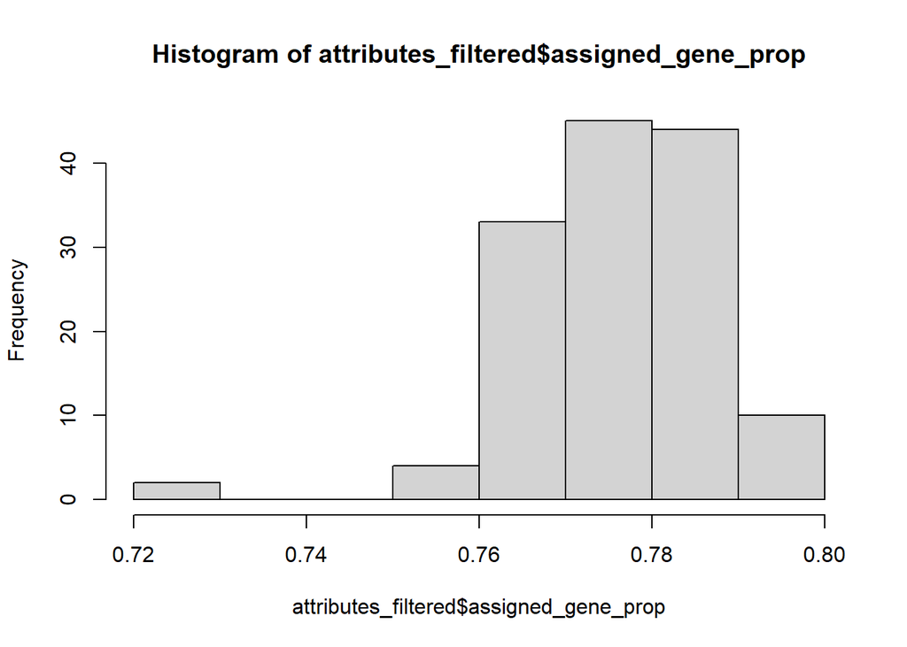

```r
attributes_filtered <- attributes
hist(attributes_filtered$assigned_gene_prop)
```

```r
table(attributes_filtered$assigned_gene_prop < 0.75)
```

```
##
## FALSE  TRUE
##   136     2
```

```r
attributes_filtered <- attributes[, attributes$assigned_gene_prop > 0.75]
```

- Eliminar genes según su media de expresión.

```r
expression_means <- rowMeans(assay(attributes_filtered, "counts"))
attributes_without <- attributes_filtered[expression_means > 0.1, ]
```

- Normalizar datos.

```r
dge <- DGEList(
  counts = assay(attributes_without, "counts"),
  genes = rowData(attributes_without)
)
dge <- calcNormFactors(dge)
```

- Expresión diferencial.

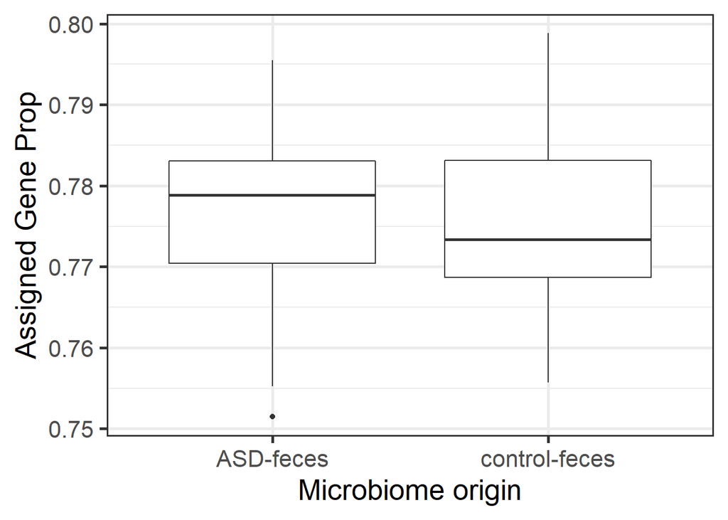

```r
ggplot(as.data.frame(colData(attributes_without)), aes(y = assigned_gene_prop, x = sra_attribute.mouse_status)) +
  geom_boxplot() +
  theme_bw(base_size = 20) +
  ylab("Assigned Gene Prop") +
  xlab("Microbiome origin")
```

- Model matrix con atributos de interés.

```r
mod <- model.matrix(~ sra_attribute.mouse_status + sra_attribute.source_name + sra_attribute.tissue + assigned_gene_prop, data = colData(attributes_without))
colnames(mod)
```

```
##  [1] "(Intercept)"
##  [2] "sra_attribute.mouse_statuscontrol-feces"
##  [3] "sra_attribute.source_namePrefrontalCortex_ASD 17"
##  [4] "sra_attribute.source_namePrefrontalCortex_ASD 24"
##  [5] "sra_attribute.source_namePrefrontalCortex_ASD 3"
##  [6] "sra_attribute.source_namePrefrontalCortex_ASD 9"
##  [7] "sra_attribute.source_namePrefrontalCortex_control 1"
##  [8] "sra_attribute.source_namePrefrontalCortex_control 4"
##  [9] "sra_attribute.source_namePrefrontalCortex_control 5"
## [10] "sra_attribute.source_nameStriatum_ASD 11"
## [11] "sra_attribute.source_nameStriatum_ASD 17"
## [12] "sra_attribute.source_nameStriatum_ASD 24"
## [13] "sra_attribute.source_nameStriatum_ASD 3"
## [14] "sra_attribute.source_nameStriatum_ASD 9"
## [15] "sra_attribute.source_nameStriatum_control 1"
## [16] "sra_attribute.source_nameStriatum_control 4"
## [17] "sra_attribute.source_nameStriatum_control 5"
## [18] "sra_attribute.tissuemacro-dissected Striatum"
## [19] "assigned_gene_prop"
```

- Hacer gráfica voom con limma.

```
## Coefficients not estimable: sra_attribute.source_nameStriatum_control 5 sra_attribute.tissuemacro-dissected Striatum
```

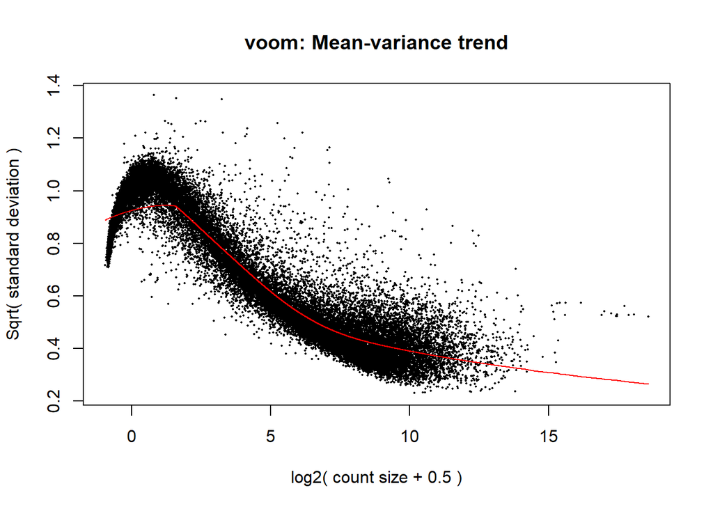

```r
vGene <- voom(dge, mod, plot = TRUE)
```

- Ajustar resultados.

```r
eb_results <- eBayes(lmFit(vGene))
```

```
## Coefficients not estimable: sra_attribute.source_nameStriatum_control 5 sra_attribute.tissuemacro-dissected Striatum
```

```r
de_results <- topTable(eb_results, coef = 2, number = nrow(attributes_without),
                       sort.by = "none"
)
table(de_results$adj.P.Val < 0.05)
```

```
##
## FALSE  TRUE
## 23533  8637
```

- Visualizar resultados estadísticos.

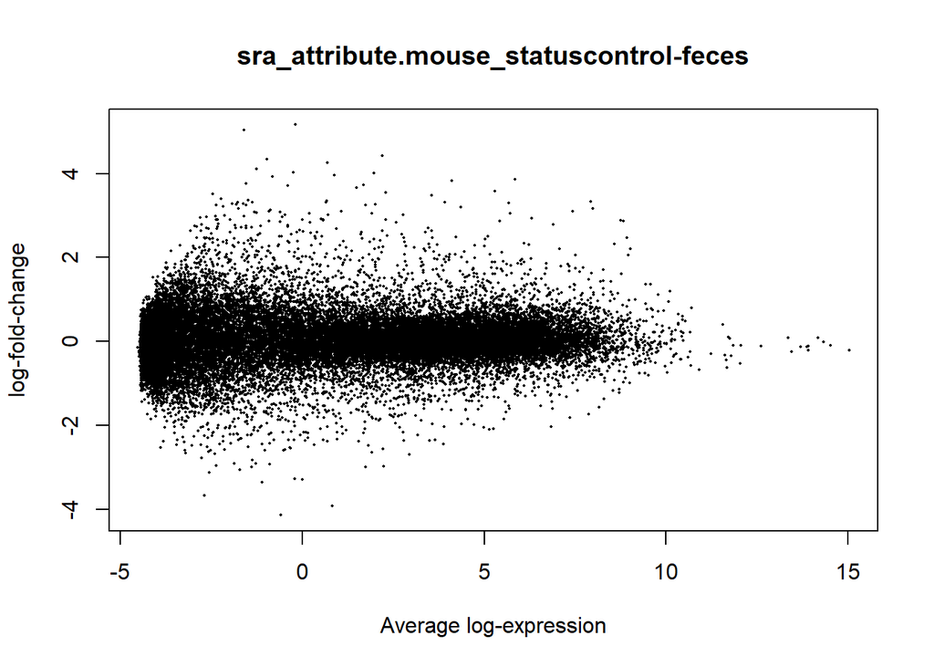

```r
plotMA(eb_results, coef = 2)
```

- Volcano plot.

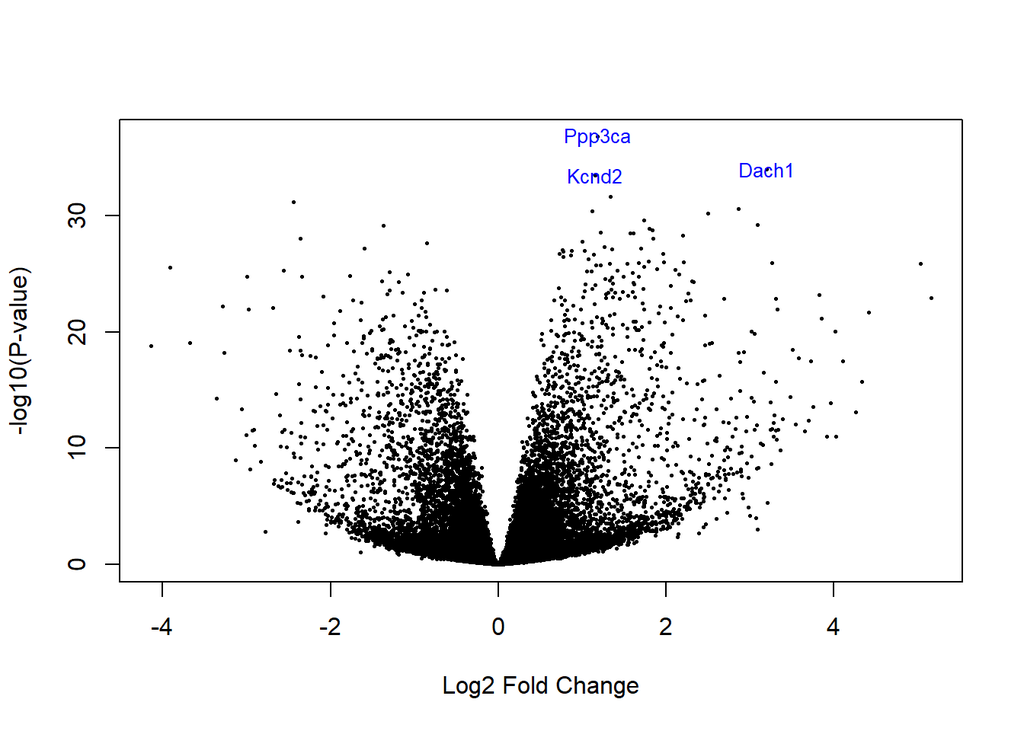

```r
volcanoplot(eb_results, coef = 2, highlight = 3, names = de_results$gene_name)
```

- Ver los 50 genes diferencialmente más expresados.

```r
exprs_heatmap <- vGene$E[rank(de_results$adj.P.Val) <= 50, ]

df <- as.data.frame(colData(attributes_without)[, c("sra_attribute.source_name", "sra_attribute.mouse_status")])
colnames(df) <- c("Source name", "Fecal origin")
```

- Heatmap

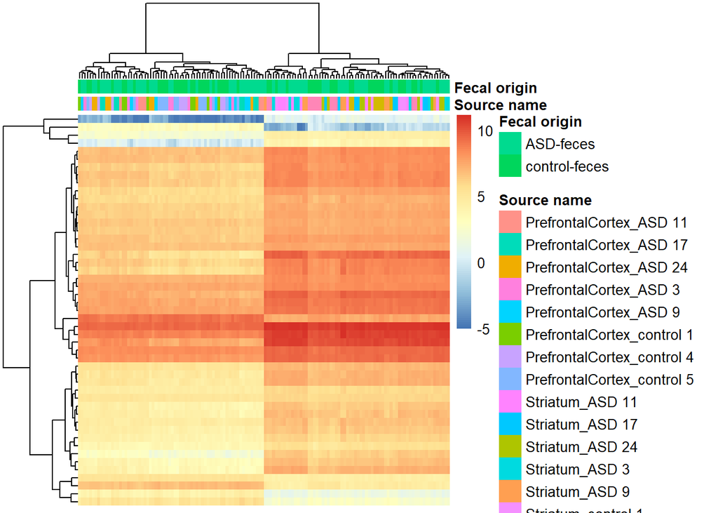

```r
pheatmap(
  exprs_heatmap,
  cluster_rows = TRUE,
  cluster_cols = TRUE,
  show_rownames = FALSE,
  show_colnames = FALSE,
  annotation_col = df
)
```

# Resultados

# Conclusiones

# Bibliografía

- Página de exploración de estudios de recount3: https://jhubiostatistics.shinyapps.io/recount3-study-explorer/
- Link compartido por Leonardo Collado: https://lcolladotor.github.io/rnaseq_LCG-UNAM_2022/modelos-estad%C3%ADsticos.html#espec%C3%ADficaciones-del-proyecto